# NYPD Shooting Incident Data

Catherine Haynes

2024-11-25

### Import libraries

```r
library(tidyverse)
```

```r
library(dplyr)
library(ggplot2)
```

### Import the NYPD Shooting Incident Data

```r
NYPD_url <- "https://data.cityofnewyork.us/api/views/833y-fsy8/rows.csv?accessType=DOWNLOAD"
NYPD <- read_csv(NYPD_url)
```

### Preview the data

```r
NYPD
```

```
## # A tibble: 28,562 × 21
##    INCIDENT_KEY OCCUR_DATE OCCUR_TIME BORO      LOC_OF_OCCUR_DESC PRECINCT
##           <dbl> <chr>      <time>     <chr>     <chr>                <dbl>
##  1    244608249 05/05/2022 00:10      MANHATTAN INSIDE                  14
##  2    247542571 07/04/2022 22:20      BRONX     OUTSIDE                 48
##  3     84967535 05/27/2012 19:35      QUEENS    <NA>                   103
##  4    202853370 09/24/2019 21:00      BRONX     <NA>                    42
##  5     27078636 02/25/2007 21:00      BROOKLYN  <NA>                    83
##  6    230311078 07/01/2021 23:07      MANHATTAN <NA>                    23
##  7    229224142 06/07/2021 19:55      QUEENS    <NA>                   113
##  8    231246224 07/22/2021 01:47      BROOKLYN  <NA>                    77
##  9    228559720 05/22/2021 18:39      BRONX     <NA>                    48
## 10    238210279 12/22/2021 23:17      BRONX     <NA>                    49
## # ℹ 28,552 more rows
## # ℹ 15 more variables: JURISDICTION_CODE <dbl>, LOC_CLASSFCTN_DESC <chr>,
## #   LOCATION_DESC <chr>, STATISTICAL_MURDER_FLAG <lgl>, PERP_AGE_GROUP <chr>,
## #   PERP_SEX <chr>, PERP_RACE <chr>, VIC_AGE_GROUP <chr>, VIC_SEX <chr>,
## #   VIC_RACE <chr>, X_COORD_CD <dbl>, Y_COORD_CD <dbl>, Latitude <dbl>,
## #   Longitude <dbl>, Lon_Lat <chr>
```

### Summarize The Data

```r
summary(NYPD)
```

```
##   INCIDENT_KEY        OCCUR_DATE         OCCUR_TIME           BORO
##  Min.   :  9953245   Length:28562       Length:28562      Length:28562
##  1st Qu.: 65439914   Class :character   Class1:hms        Class :character
##  Median : 92711254   Mode  :character   Class2:difftime   Mode  :character
##  Mean   :127405824                      Mode  :numeric
##  3rd Qu.:203131993
##  Max.   :279758069
##
##  LOC_OF_OCCUR_DESC     PRECINCT     JURISDICTION_CODE LOC_CLASSFCTN_DESC
##  Length:28562       Min.   :  1.0   Min.   :0.0000    Length:28562
##  Class :character   1st Qu.: 44.0   1st Qu.:0.0000    Class :character
##  Mode  :character   Median : 67.0   Median :0.0000    Mode  :character
##                     Mean   : 65.5   Mean   :0.3219
##                     3rd Qu.: 81.0   3rd Qu.:0.0000
##                     Max.   :123.0   Max.   :2.0000
##                                     NA's   :2
##  LOCATION_DESC      STATISTICAL_MURDER_FLAG PERP_AGE_GROUP
##  Length:28562       Mode :logical           Length:28562
##  Class :character   FALSE:23036             Class :character
##  Mode  :character   TRUE :5526              Mode  :character
##
##
##
##
##    PERP_SEX          PERP_RACE         VIC_AGE_GROUP        VIC_SEX
##  Length:28562       Length:28562       Length:28562       Length:28562
##  Class :character   Class :character   Class :character   Class :character
##  Mode  :character   Mode  :character   Mode  :character   Mode  :character
##
##
##
##
##    VIC_RACE           X_COORD_CD        Y_COORD_CD        Latitude
##  Length:28562       Min.   : 914928   Min.   :125757   Min.   :40.51
##  Class :character   1st Qu.:1000068   1st Qu.:182912   1st Qu.:40.67
##  Mode  :character   Median :1007772   Median :194901   Median :40.70
##                     Mean   :1009424   Mean   :208380   Mean   :40.74
##                     3rd Qu.:1016807   3rd Qu.:239814   3rd Qu.:40.82
##                     Max.   :1066815   Max.   :271128   Max.   :40.91
##                                                        NA's   :59
##    Longitude        Lon_Lat
##  Min.   :-74.25   Length:28562
##  1st Qu.:-73.94   Class :character
##  Median :-73.92   Mode  :character
##  Mean   :-73.91
##  3rd Qu.:-73.88
##  Max.   :-73.70
##  NA's   :59
```

```r
colnames(NYPD)
```

```
##  [1] "INCIDENT_KEY"            "OCCUR_DATE"
##  [3] "OCCUR_TIME"              "BORO"
##  [5] "LOC_OF_OCCUR_DESC"       "PRECINCT"
##  [7] "JURISDICTION_CODE"       "LOC_CLASSFCTN_DESC"
##  [9] "LOCATION_DESC"           "STATISTICAL_MURDER_FLAG"
## [11] "PERP_AGE_GROUP"          "PERP_SEX"
## [13] "PERP_RACE"               "VIC_AGE_GROUP"
## [15] "VIC_SEX"                 "VIC_RACE"
## [17] "X_COORD_CD"              "Y_COORD_CD"
## [19] "Latitude"                "Longitude"
## [21] "Lon_Lat"
```

### Clean Up Data Types & Unneeded Columns For Analysis

```r
NYPD$OCCUR_DATE <- as.Date(NYPD$OCCUR_DATE, format = "%m/%d/%Y")
NYPD$PERP_AGE_GROUP <- as.factor(NYPD$PERP_AGE_GROUP)
NYPD$PERP_SEX <- as.factor(NYPD$PERP_SEX)
NYPD$PERP_RACE <- as.factor(NYPD$PERP_RACE)
NYPD$VIC_AGE_GROUP <- as.factor(NYPD$VIC_AGE_GROUP)
NYPD$VIC_SEX <- as.factor(NYPD$VIC_SEX)
NYPD$VIC_RACE <- as.factor(NYPD$VIC_RACE)
NYPD$INCIDENT_KEY <- as.character((NYPD$INCIDENT_KEY))
NYPD$BORO <- as.factor(NYPD$BORO)
NYPD$LOC_OF_OCCUR_DESC <- as.factor(NYPD$LOC_OF_OCCUR_DESC)
NYPD$PRECINCT <- as.character(NYPD$PRECINCT)
NYPD$JURISDICTION_CODE <- as.character(NYPD$JURISDICTION_CODE)

NYPD <- NYPD %>%
  select(-X_COORD_CD, -Y_COORD_CD, -Latitude, -Longitude, -Lon_Lat)

NYPD
```

```
## # A tibble: 28,562 × 16
##    INCIDENT_KEY OCCUR_DATE OCCUR_TIME BORO      LOC_OF_OCCUR_DESC PRECINCT
##    <chr>        <date>     <time>     <fct>     <fct>             <chr>
##  1 244608249    2022-05-05 00:10      MANHATTAN INSIDE            14
##  2 247542571    2022-07-04 22:20      BRONX     OUTSIDE           48
##  3 84967535     2012-05-27 19:35      QUEENS    <NA>              103
##  4 202853370    2019-09-24 21:00      BRONX     <NA>              42
##  5 27078636     2007-02-25 21:00      BROOKLYN  <NA>              83
##  6 230311078    2021-07-01 23:07      MANHATTAN <NA>              23
##  7 229224142    2021-06-07 19:55      QUEENS    <NA>              113
##  8 231246224    2021-07-22 01:47      BROOKLYN  <NA>              77
##  9 228559720    2021-05-22 18:39      BRONX     <NA>              48
## 10 238210279    2021-12-22 23:17      BRONX     <NA>              49
## # ℹ 28,552 more rows
## # ℹ 10 more variables: JURISDICTION_CODE <chr>, LOC_CLASSFCTN_DESC <chr>,
## #   LOCATION_DESC <chr>, STATISTICAL_MURDER_FLAG <lgl>, PERP_AGE_GROUP <fct>,
## #   PERP_SEX <fct>, PERP_RACE <fct>, VIC_AGE_GROUP <fct>, VIC_SEX <fct>,
## #   VIC_RACE <fct>
```

```r
summary(NYPD)
```

```
##  INCIDENT_KEY         OCCUR_DATE          OCCUR_TIME
##  Length:28562       Min.   :2006-01-01   Length:28562
##  Class :character   1st Qu.:2009-09-04   Class1:hms
##  Mode  :character   Median :2013-09-20   Class2:difftime
##                     Mean   :2014-06-07   Mode  :numeric
##                     3rd Qu.:2019-09-29
##                     Max.   :2023-12-29
##
##             BORO       LOC_OF_OCCUR_DESC   PRECINCT         JURISDICTION_CODE
##  BRONX        : 8376   INSIDE :  460     Length:28562       Length:28562
##  BROOKLYN     :11346   OUTSIDE: 2506     Class :character   Class :character
##  MANHATTAN    : 3762   NA's   :25596     Mode  :character   Mode  :character
##  QUEENS       : 4271
##  STATEN ISLAND:  807
##
##
##  LOC_CLASSFCTN_DESC LOCATION_DESC      STATISTICAL_MURDER_FLAG PERP_AGE_GROUP
##  Length:28562       Length:28562       Mode :logical           18-24  :6438
##  Class :character   Class :character   FALSE:23036             25-44  :6041
##  Mode  :character   Mode  :character   TRUE :5526              UNKNOWN:3148
##                                                                <18    :1682
##                                                                (null) :1141
##                                                                (Other): 768
##                                                                NA's   :9344
##    PERP_SEX              PERP_RACE     VIC_AGE_GROUP   VIC_SEX
##  (null): 1141   BLACK         :11903   <18    : 2954   F: 2760
##  F     :  444   WHITE HISPANIC: 2510   1022   :    1   M:25790
##  M     :16168   UNKNOWN       : 1837   18-24  :10384   U:   12
##  U     : 1499   BLACK HISPANIC: 1392   25-44  :12973
##  NA's  : 9310   (null)        : 1141   45-64  : 1981
##                 (Other)       :  469   65+    :  205
##                 NA's          : 9310   UNKNOWN:   64
##                            VIC_RACE
##  AMERICAN INDIAN/ALASKAN NATIVE:   11
##  ASIAN / PACIFIC ISLANDER      :  440
##  BLACK                         :20235
##  BLACK HISPANIC                : 2795
##  UNKNOWN                       :   70
##  WHITE                         :  728
##  WHITE HISPANIC                : 4283
```

### Total Incidents and Deaths per Year

The following table and graph show how the number of incidents and statistical murders have changed over the years. Please note date ranges from 1-1-2006 to 12-29-2023.

```r
totals_by_year <- NYPD %>%
  mutate(Year = format(OCCUR_DATE, "%Y")) %>%
  group_by(Year) %>%
  summarize(
    incidents = n(),
    murders = sum(STATISTICAL_MURDER_FLAG)
  ) %>%
  select(Year, incidents, murders)

totals_by_year
```

```
## # A tibble: 18 × 3
##    Year  incidents murders
##    <chr>     <int>   <int>
##  1 2006       2055     445
##  2 2007       1887     373
##  3 2008       1959     362
##  4 2009       1828     348
##  5 2010       1912     405
##  6 2011       1939     373
##  7 2012       1717     288
##  8 2013       1339     223
##  9 2014       1464     249
## 10 2015       1434     283
## 11 2016       1208     223
## 12 2017        970     174
## 13 2018        958     204
## 14 2019        967     184
## 15 2020       1948     366
## 16 2021       2011     428
## 17 2022       1716     338
## 18 2023       1250     260
```

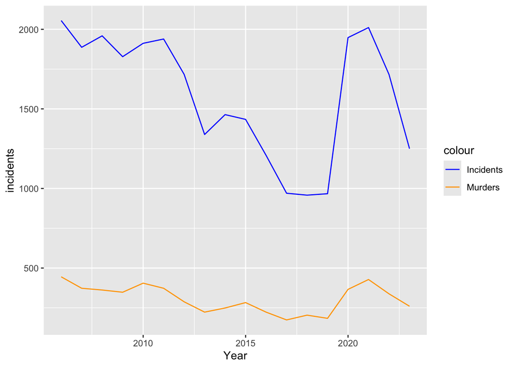

```r
totals_by_year$Year <- as.numeric(totals_by_year$Year)
ggplot(data = totals_by_year) +
  geom_line(aes(x= Year, y = incidents, color = 'Incidents')) +
  geom_line(aes(x= Year, y = murders, color = 'Murders')) +
  scale_color_manual(values = c('Incidents' = 'blue', 'Murders' = 'orange'))
```

### Total Indicidents by Borough in 2023

The following table and graph show the total incidents in 2023, separated by the NYC borough that they occurred in.

```r
totals_by_boro <- NYPD %>%
  filter(format(OCCUR_DATE, "%Y") == "2023") %>%
  group_by(BORO) %>%
  summarize(
    incidents = n(),
    murders = sum(STATISTICAL_MURDER_FLAG)
  ) %>%
  select(BORO, incidents, murders)

totals_by_boro
```

```
## # A tibble: 5 × 3
##   BORO          incidents murders
##   <fct>             <int>   <int>
## 1 BRONX               439      92
## 2 BROOKLYN            413      88
## 3 MANHATTAN           190      42
## 4 QUEENS              177      30
## 5 STATEN ISLAND        31       8
```

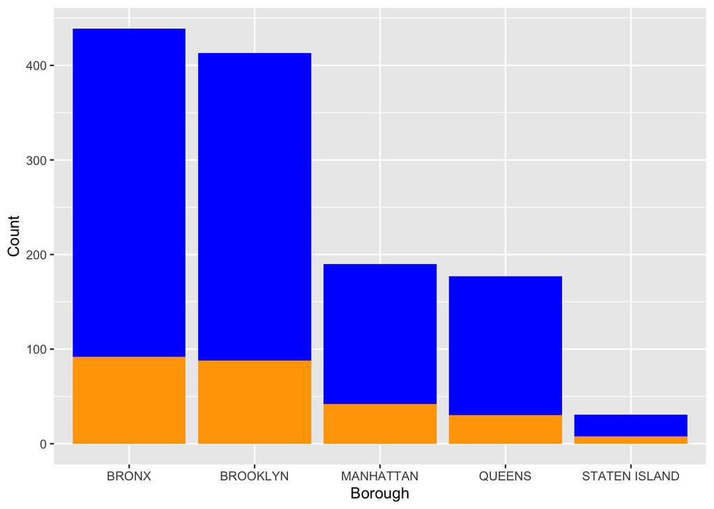

```r
ggplot(data = totals_by_boro) +
  geom_bar(aes(x= interaction(BORO), y = incidents), stat = "identity", fill = 'blue') +
  geom_bar(aes(x= interaction(BORO), y = murders), stat = "identity", fill = 'orange') +
  labs(x= "Borough",
       y = "Count")
```

### Analysis - Incidents as a Ratio of the population in Each Borough in 2023

Looking at total incidents, the Bronx had only 26 more incidents that Brooklyn in 2023. But when we look at incidents per hundred thousand, we see that the Bronx had significantly more incidents. For every hundred thousand people in population, the Bronx had 32 incidents, where Brooklyn had 16.

Population data retrieved from: https://www.nyc.gov/assets/planning/download/pdf/planning-level/nyc-population/population-estimates/current-population-estimates-2023-June2024-release.pdf?r=1

```r
pop_by_boro <- data.frame(
  BORO = c("MANHATTAN", "BROOKLYN", "QUEENS", "BRONX", "STATEN ISLAND"),
  Population_2023 = c(1597451, 2561225, 2252196, 1356476, 490687)
)

ratio_by_boro <- NYPD %>%
  filter(format(OCCUR_DATE, "%Y") == "2023") %>%
  group_by(BORO) %>%
  summarize(
    incidents = n(),
    murders = sum(STATISTICAL_MURDER_FLAG)
  ) %>%
  left_join(pop_by_boro, by = "BORO") %>%
  mutate(
    incidents_per_hunthousand = (incidents / Population_2023) * 100000,
    murders_per_hunthousand = (murders / Population_2023) * 100000
  ) %>%
  select(BORO, incidents, murders, Population_2023, incidents_per_hunthousand, murders_per_hunthousand)

ratio_by_boro
```

```
## # A tibble: 5 × 6
##   BORO          incidents murders Population_2023 incidents_per_hunthousand
##   <chr>             <int>   <int>           <dbl>                     <dbl>
## 1 BRONX               439      92         1356476                     32.4
## 2 BROOKLYN            413      88         2561225                     16.1
## 3 MANHATTAN           190      42         1597451                     11.9
## 4 QUEENS              177      30         2252196                      7.86
## 5 STATEN ISLAND        31       8          490687                      6.32
## # ℹ 1 more variable: murders_per_hunthousand <dbl>
```

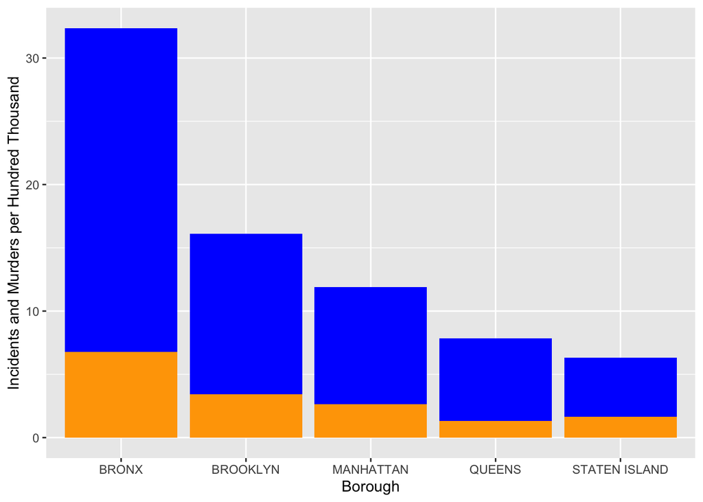

```r
ggplot(data = ratio_by_boro) +
  geom_bar(aes(x= BORO, y = incidents_per_hunthousand), stat = "identity", fill = 'blue') +
  geom_bar(aes(x= BORO, y = murders_per_hunthousand), stat = "identity", fill = 'orange') +
  labs(x= "Borough",
       y = "Incidents and Murders per Hundred Thousand")
```

The analysis reveals a statistically significant relationship between incidents and murders, suggesting that the number of incidents per hundred thousand serves as a strong predictor for estimating murders per hundred thousand.

```r
mod <- lm(ratio_by_boro$murders_per_hunthousand ~ ratio_by_boro$incidents_per_hunthousand)
summary(mod)
```

```
##
## Call:
## lm(formula = ratio_by_boro$murders_per_hunthousand ~ ratio_by_boro$incidents_per_hunthousand)
##
## Residuals:
##         1         2         3         4         5
## -0.006871  0.021732  0.094489 -0.364021  0.254670
##
## Coefficients:
##                                         Estimate Std. Error t value Pr(>|t|)
## (Intercept)                              0.06260    0.22074   0.284 0.795175
## ratio_by_boro$incidents_per_hunthousand  0.20785    0.01254  16.581 0.000478
##
## (Intercept)
## ratio_by_boro$incidents_per_hunthousand ***
## ---
## Signif. codes:  0 '***' 0.001 '**' 0.01 '*' 0.05 '.' 0.1 ' ' 1
##
## Residual standard error: 0.2626 on 3 degrees of freedom
## Multiple R-squared:  0.9892, Adjusted R-squared:  0.9856
## F-statistic: 274.9 on 1 and 3 DF,  p-value: 0.0004775
```

```r
ratio_by_boro_w_pred <- ratio_by_boro %>% mutate(pred=predict(mod))
ratio_by_boro_w_pred
```

```
## # A tibble: 5 × 7
##   BORO          incidents murders Population_2023 incidents_per_hunthousand
##   <chr>             <int>   <int>           <dbl>                     <dbl>
## 1 BRONX               439      92         1356476                     32.4
## 2 BROOKLYN            413      88         2561225                     16.1
## 3 MANHATTAN           190      42         1597451                     11.9
## 4 QUEENS              177      30         2252196                      7.86
## 5 STATEN ISLAND        31       8          490687                      6.32
## # ℹ 2 more variables: murders_per_hunthousand <dbl>, pred <dbl>
```

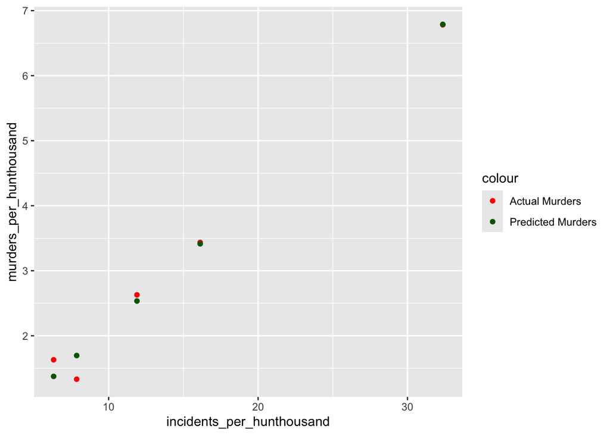

```r
ratio_by_boro_w_pred %>% ggplot() +
  geom_point(aes(x = incidents_per_hunthousand, y = murders_per_hunthousand, color = 'Actual Murders')) +
  geom_point(aes(x = incidents_per_hunthousand, y=pred, color = 'Predicted Murders')) +
  scale_color_manual(values = c('Actual Murders' = 'red', 'Predicted Murders'= 'darkgreen'))
```

### Total Incidents by Hour of the Day

The following table and graph give us an idea of what time of day incidents are most likely to occur. Incidents are lowest in the morning and then continue to increase for every hour of the rest of the day. Incidents then begin to decrease again after midnight.

```r
total_by_hour <- NYPD %>%
  mutate(Hour = substr(as.character(NYPD$OCCUR_TIME), 1, 2)) %>%
  group_by(Hour) %>%
  summarize(
    incidents = n(),
    murders = sum(STATISTICAL_MURDER_FLAG)
  ) %>%
  select(Hour, incidents, murders)

total_by_hour
```

```
## # A tibble: 24 × 3
##    Hour  incidents murders
##    <chr>     <int>   <int>
##  1 00         2267     403
##  2 01         2142     373
##  3 02         1878     329
##  4 03         1666     286
##  5 04         1487     305
##  6 05          738     178
##  7 06          389      92
##  8 07          246      74
##  9 08          254      68
## 10 09          240      55
## # ℹ 14 more rows
```

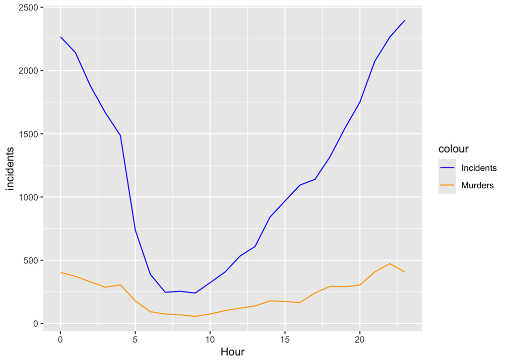

```r
total_by_hour$Hour <- as.numeric(total_by_hour$Hour)
ggplot(data = total_by_hour) +
  geom_line(aes(x= Hour, y = incidents, color = 'Incidents')) +
  geom_line(aes(x= Hour, y = murders, color = 'Murders')) +
  scale_color_manual(values = c('Incidents'='blue', 'Murders'='orange'))
```

### Conclusion and Bias

Because this is open source data, the likelihood for personal bias is low. However, there is still potential for bias to be present in the collection of data and in the analysis. The data set only includes shooting incidents that were reported to or by the NYPD. It is possible that there are shooting incidents that were not recorded but occured and would potentially change the analysis outcomes. In regards to personal bias, when I was analyzing the change of incidents over time, I had preconceived assumptions that incidents would rise in 2020. In order to mitigate my assumptions and bias, I reported on all data present and did nothing to remove data that did not fit my assumptions. I let the data speak for its own trends and didn’t try to prove my assumptions correct.